# ReneWind

## Context

Renewable energy sources play an increasingly important role in the global energy mix, as the effort to reduce the environmental impact of energy production increases.

Out of all the renewable energy alternatives, wind energy is one of the most developed technologies worldwide. The U.S Department of Energy has put together a guide to achieving operational efficiency using predictive maintenance practices.

Predictive maintenance uses sensor information and analysis methods to measure and predict degradation and future component capability. The idea behind predictive maintenance is that failure patterns are predictable and if component failure can be predicted accurately and the component is replaced before it fails, the costs of operation and maintenance will be much lower.

The sensors fitted across different machines involved in the process of energy generation collect data related to various environmental factors (temperature, humidity, wind speed, etc.) and additional features related to various parts of the wind turbine (gearbox, tower, blades, break, etc.).

## Objective

*ReneWind* is a company working on improving the machinery/processes involved in the production of wind energy using machine learning and has collected data of generator failure of wind turbines using sensors. They have shared a ciphered version of the data, as the data collected through sensors is confidential (the type of data collected varies with companies). Data has 40 predictors, 40,000 observations in the training set and 10,000 in the test set.

The objective is to build various classification models, tune them and find the best one that will help identify failures so that the generator could be repaired before failing/breaking and the overall maintenance cost of the generators can be brought down.

“1” in the target variables should be considered as “failure” and “0” will represent “No failure”.

The nature of predictions made by the classification model will translate as follows:

- True positives (TP) are failures correctly predicted by the model.
- False negatives (FN) are real failures in the generator of wind turbine where there is no detection by the model.
- False positives (FP) are failure detections in the generator of the wind turbine where actually there is no failure.

So, the maintenance cost associated with the model would be:

- Maintenance cost = `TP*(Repair cost) + FN*(Replacement cost) + FP*(Inspection cost)` where,
- `Replacement cost = $40,000`
- `Repair cost = $15,000`
- `Inspection cost = $5,000` Here the objective is to reduce the maintenance cost so, we want a metric that could reduce the maintenance cost.

The minimum possible maintenance cost = `Actual failures*(Repair cost) = (TP + FN)*(Repair cost)`

And the maintenance cost associated with model = `TP*(Repair cost) + FN*(Replacement cost) + FP*(Inspection cost)`

So, we will try to maximize the ratio of minimum possible maintenance cost and the maintenance cost associated with the model.

The value of this ratio will lie between 0 and 1, the ratio will be 1 only when the maintenance cost associated with the model will be equal to the minimum possible maintenance cost.

## Data Description

- The data provided is a transformed version of original data which was collected using sensors.
- **Train.csv** - To be used for training and tuning of models.
- **Test.csv** - To be used only for testing the performance of the final best model.
- Both the datasets consist of 40 predictor variables and 1 target variable

## Note

Once the data is ready, start with the steps that need to be followed as mentioned in the rubric

- Build 6 models with original data
- Build 6 models with oversampled data
- Build 6 models with undersampled data
- Choose 3 best models among 18 models built in the previous 3 steps
- Tune 3 models
- Choose one best model and productionize it using pipelines

# Importing libraries

```python
# To help with reading and manipulating data
import timeit
start = timeit.default_timer()

import pandas as pd
import numpy as np
from scipy.stats import randint as sp_randint

# To help with data visualization
%matplotlib inline
import matplotlib.pyplot as plt
import seaborn as sns

# To be used for missing value imputation
from sklearn.impute import SimpleImputer
from sklearn.impute import KNNImputer

# To help with model building
from sklearn.linear_model import LogisticRegression
from sklearn.tree import DecisionTreeClassifier
from sklearn.ensemble import (
    AdaBoostClassifier,
    GradientBoostingClassifier,
    RandomForestClassifier,
    BaggingClassifier,
)
from xgboost import XGBClassifier

# To get different metric scores, and split data
from sklearn import metrics
from sklearn.model_selection import train_test_split, StratifiedKFold, cross_val_score
from sklearn.metrics import (
    f1_score,
    accuracy_score,
    recall_score,
    precision_score,
    confusion_matrix,
    roc_auc_score,
    plot_confusion_matrix,
)

# To be used for data scaling and one hot encoding
from sklearn.preprocessing import StandardScaler, MinMaxScaler, OneHotEncoder

# For oversampling and undersampling
from imblearn.over_sampling import SMOTE
from imblearn.under_sampling import RandomUnderSampler

# To be used for tuning the model
from sklearn.model_selection import GridSearchCV, RandomizedSearchCV

# To be used for creating pipelines and personalizing them
from sklearn.pipeline import Pipeline
from sklearn.compose import ColumnTransformer

# To define maximum number of columns to be displayed in a dataframe
pd.set_option("display.max_columns", None)

# To supress scientific notations for a dataframe
pd.set_option("display.float_format", lambda x: "%.3f" % x)

# To supress warnings
import warnings

warnings.filterwarnings("ignore")

# This will help in making the Python code more structured automatically (good coding practice)
%load_ext nb_black
```

# Loading Data

```python
# from google.colab import files

# uploaded = files.upload()
```

```python
train = pd.read_csv('Train.csv')
```

```python
train.shape
```

```
(40000, 41)
```

```python
test = pd.read_csv('Test.csv')
```

```python
test.shape
```

```
(10000, 41)
```

- The train dataset has 40,000 rows and 41 columns.
- The test dataset has 10,000 rows and 41 columns.

## Data Overview

```python
# create a copy of the data
df = train.copy()

# view a sample of the data
df.sample(n=10)
```

|  | V1 | V2 | V3 | V4 | V5 | V6 | V7 | V8 | V9 | V10 | V11 | V12 | V13 | V14 | V15 | V16 | V17 | V18 | V19 | V20 | V21 | V22 | V23 | V24 | V25 | V26 | V27 | V28 | V29 | … |
| --- | --- | --- | --- | --- | --- | --- | --- | --- | --- | --- | --- | --- | --- | --- | --- | --- | --- | --- | --- | --- | --- | --- | --- | --- | --- | --- | --- | --- | --- | --- |
| 13915 | -1.974 | -0.322 | 1.735 | -0.713 | 0.979 | -1.366 | -1.720 | 0.606 | -0.434 | -0.865 | -4.037 | 2.744 | 1.546 | -0.742 | -3.862 | -3.148 | 1.973 | 3.760 | -0.551 | 1.371 | -3.707 | 1.855 | 1.968 | 2.612 | -0.111 | 1.155 | -2.756 | -0.874 | -1.487 | … |
| 8010 | 0.196 | -2.707 | 3.063 | -2.963 | -2.323 | -3.716 | -1.160 | 1.220 | 1.706 | -1.691 | -6.442 | 7.217 | 6.526 | 0.463 | -5.336 | -5.931 | 2.895 | 4.263 | 0.183 | 7.009 | -6.908 | 3.857 | 2.652 | -4.534 | 3.314 | -1.887 | 2.727 | -1.158 | -5.193 | … |
| 4893 | 4.457 | 3.985 | -1.292 | 2.959 | -0.102 | -0.485 | 0.766 | -1.216 | 3.779 | -2.775 | -0.488 | -2.043 | 0.868 | -0.729 | -0.856 | -3.639 | 2.120 | -1.437 | -0.091 | -0.438 | -3.000 | 2.291 | 2.135 | -0.142 | 0.529 | 2.685 | -0.752 | 0.275 | -1.786 | … |
| 914 | -3.406 | -4.536 | 5.696 | 2.276 | -2.923 | -3.086 | -3.846 | 1.502 | 0.088 | 0.531 | -2.771 | 0.979 | 3.361 | -0.067 | -4.715 | -2.590 | 0.660 | 0.441 | 3.718 | 7.282 | -5.281 | -1.023 | -3.855 | -1.494 | 0.385 | -1.673 | -2.535 | -0.888 | 1.319 | … |
| 2421 | -3.419 | 3.273 | 0.163 | 4.353 | 1.463 | -2.445 | 1.463 | 2.754 | -2.533 | -0.878 | -2.043 | 5.210 | -3.561 | -2.291 | 2.071 | 2.167 | 5.361 | -1.903 | 5.005 | 1.094 | 1.929 | -0.856 | 1.645 | 5.561 | -1.395 | 1.152 | -5.797 | 2.645 | 0.217 | … |
| 3748 | -2.158 | -1.117 | -3.553 | -0.558 | 1.836 | -2.755 | -0.436 | 4.880 | -2.151 | -1.599 | -6.266 | 7.199 | -0.479 | 0.486 | -2.582 | -0.814 | 6.887 | 5.379 | -0.687 | 3.138 | -1.842 | 5.233 | 10.513 | 7.199 | -0.405 | -2.955 | -5.157 | 1.605 | -3.925 | … |
| 19308 | -2.502 | -0.848 | -0.450 | -1.772 | -0.956 | -0.135 | -0.863 | -1.374 | 1.161 | -1.604 | -0.000 | 3.934 | 4.894 | -0.739 | -5.324 | -3.394 | -0.620 | 2.996 | -0.141 | 1.785 | -3.239 | 1.675 | 1.747 | -3.116 | -0.862 | -0.061 | -0.011 | -0.923 | -0.053 | … |
| 28195 | -0.613 | -2.313 | 0.902 | -6.185 | 0.572 | 1.374 | -2.974 | -2.266 | 2.012 | -2.375 | -3.144 | 0.558 | 4.650 | -0.007 | -6.746 | -6.310 | -0.344 | 8.358 | -6.821 | 1.136 | -5.151 | 3.141 | 1.563 | -3.209 | 1.302 | 0.241 | 0.909 | -3.194 | -0.881 | … |
| 29145 | -2.073 | -0.622 | -1.426 | -0.494 | 0.957 | -3.341 | -0.811 | 4.600 | -2.031 | -1.162 | -3.335 | 7.733 | 4.182 | 0.301 | -5.524 | -0.088 | 1.694 | 3.055 | 0.639 | 0.594 | -4.772 | 4.228 | 9.382 | 5.447 | -2.474 | 0.749 | -4.680 | -1.139 | -2.591 | … |
| 28609 | -0.359 | -4.654 | 1.391 | -7.079 | -2.058 | 2.075 | -0.409 | -2.510 | -1.798 | 4.173 | 4.215 | 1.512 | 5.308 | 1.604 | -2.291 | 0.305 | -9.992 | 1.458 | -0.760 | -3.756 | -1.455 | -0.212 | -2.397 | -4.837 | -0.656 | -1.045 | 7.967 | -3.150 | 0.336 | … |

```python
# check data types of the columns in the dataset
df.info()
```

```
<class 'pandas.core.frame.DataFrame'>
RangeIndex: 40000 entries, 0 to 39999
Data columns (total 41 columns):
 #   Column  Non-Null Count  Dtype
---  ------  --------------  -----
 0   V1      39954 non-null  float64
 1   V2      39961 non-null  float64
 2   V3      40000 non-null  float64
 3   V4      40000 non-null  float64
 4   V5      40000 non-null  float64
 5   V6      40000 non-null  float64
 6   V7      40000 non-null  float64
 7   V8      40000 non-null  float64
 8   V9      40000 non-null  float64
 9   V10     40000 non-null  float64
```

[output cut: 33 more lines]

- There are a total of 41 columns and 40,000 observations in the train dataset
- All columns besides the target variable are encoded with a cipher as a float
- V1 and V2 have 39,954 and 39,961 non-null values respectively, i.e., these columns have missing values

```python
# check for duplicate values in the train dataset
df.duplicated().sum()
```

```
0
```

```python
# check for duplicate values in the test dataset
df.duplicated().sum()
```

```
0
```

**Observation**

```python
# check for missing values in the train dataset
round(df.isnull().sum() / df.isnull().count()*100, 2)
```

```
V1       0.120
V2       0.100
V3       0.000
V4       0.000
V5       0.000
V6       0.000
V7       0.000
V8       0.000
V9       0.000
V10      0.000
V11      0.000
V12      0.000
V13      0.000
V14      0.000
V15      0.000
V16      0.000
V17      0.000
V18      0.000
V19      0.000
V20      0.000
V21      0.000
V22      0.000
V23      0.000
V24      0.000
V25      0.000
V26      0.000
V27      0.000
V28      0.000
V29      0.000
V30      0.000
V31      0.000
V32      0.000
V33      0.000
V34      0.000
V35      0.000
V36      0.000
V37      0.000
V38      0.000
V39      0.000
V40      0.000
Target   0.000
dtype: float64
```

For the train set:

- V1 has 0.12% missing values
- V2 has 0.1% missing values

```python
# check if test dataset has null values
round(test.isnull().sum() / test.isnull().count()*100, 2)
```

```
V1       0.110
V2       0.070
V3       0.000
V4       0.000
V5       0.000
V6       0.000
V7       0.000
V8       0.000
V9       0.000
V10      0.000
V11      0.000
V12      0.000
V13      0.000
V14      0.000
V15      0.000
V16      0.000
V17      0.000
V18      0.000
V19      0.000
V20      0.000
V21      0.000
V22      0.000
V23      0.000
V24      0.000
V25      0.000
V26      0.000
V27      0.000
V28      0.000
V29      0.000
V30      0.000
V31      0.000
V32      0.000
V33      0.000
V34      0.000
V35      0.000
V36      0.000
V37      0.000
V38      0.000
V39      0.000
V40      0.000
Target   0.000
dtype: float64
```

For the test set:

- V1 has 0.11% missing values
- V2 has 0.07% missing values

The test set has a smaller proportion of missing values for the respective columns, but the same columns are missing values as in the train set

```python
# view descriptive statistics of all the columns of the dataset
df.describe()
```

|  | V1 | V2 | V3 | V4 | V5 | V6 | V7 | V8 | V9 | V10 | V11 | V12 | V13 | V14 | V15 | V16 | V17 | V18 | V19 | V20 | V21 | V22 | V23 | V24 | V25 | V26 | V27 | V28 | V29 | … |
| --- | --- | --- | --- | --- | --- | --- | --- | --- | --- | --- | --- | --- | --- | --- | --- | --- | --- | --- | --- | --- | --- | --- | --- | --- | --- | --- | --- | --- | --- | --- |
| count | 39954.000 | 39961.000 | 40000.000 | 40000.000 | 40000.000 | 40000.000 | 40000.000 | 40000.000 | 40000.000 | 40000.000 | 40000.000 | 40000.000 | 40000.000 | 40000.000 | 40000.000 | 40000.000 | 40000.000 | 40000.000 | 40000.000 | 40000.000 | 40000.000 | 40000.000 | 40000.000 | 40000.000 | 40000.000 | 40000.000 | 40000.000 | 40000.000 | 40000.000 | … |
| mean | -0.288 | 0.443 | 2.506 | -0.066 | -0.045 | -1.001 | -0.893 | -0.563 | -0.008 | -0.002 | -1.918 | 1.578 | 1.591 | -0.947 | -2.436 | -2.943 | -0.143 | 1.189 | 1.181 | 0.027 | -3.621 | 0.943 | -0.388 | 1.142 | -0.003 | 1.896 | -0.617 | -0.888 | -1.005 | … |
| std | 3.449 | 3.139 | 3.406 | 3.437 | 2.107 | 2.037 | 1.757 | 3.299 | 2.162 | 2.183 | 3.116 | 2.915 | 2.865 | 1.788 | 3.341 | 4.212 | 3.344 | 2.586 | 3.395 | 3.675 | 3.557 | 1.646 | 4.052 | 3.913 | 2.025 | 3.421 | 4.392 | 1.925 | 2.676 | … |
| min | -13.502 | -13.212 | -11.469 | -16.015 | -8.613 | -10.227 | -8.206 | -15.658 | -8.596 | -11.001 | -14.832 | -13.619 | -13.830 | -8.309 | -17.202 | -21.919 | -17.634 | -11.644 | -13.492 | -13.923 | -19.436 | -10.122 | -16.188 | -18.488 | -8.228 | -12.588 | -14.905 | -9.685 | -12.579 | … |
| 25% | -2.751 | -1.638 | 0.203 | -2.350 | -1.507 | -2.363 | -2.037 | -2.660 | -1.494 | -1.391 | -3.941 | -0.431 | -0.209 | -2.165 | -4.451 | -5.632 | -2.227 | -0.403 | -1.051 | -2.434 | -5.921 | -0.112 | -3.119 | -1.483 | -1.373 | -0.319 | -3.692 | -2.193 | -2.799 | … |
| 50% | -0.774 | 0.464 | 2.265 | -0.124 | -0.097 | -1.007 | -0.935 | -0.384 | -0.052 | 0.106 | -1.942 | 1.485 | 1.654 | -0.957 | -2.399 | -2.719 | -0.028 | 0.867 | 1.278 | 0.030 | -3.559 | 0.963 | -0.275 | 0.964 | 0.021 | 1.964 | -0.910 | -0.905 | -1.206 | … |
| 75% | 1.837 | 2.538 | 4.585 | 2.149 | 1.346 | 0.374 | 0.207 | 1.714 | 1.426 | 1.486 | 0.089 | 3.541 | 3.476 | 0.266 | -0.382 | -0.113 | 2.072 | 2.564 | 3.497 | 2.513 | -1.284 | 2.018 | 2.438 | 3.563 | 1.400 | 4.163 | 2.201 | 0.377 | 0.604 | … |
| max | 17.437 | 13.089 | 18.366 | 13.280 | 9.403 | 7.065 | 8.006 | 11.679 | 8.507 | 8.108 | 13.852 | 15.754 | 15.420 | 6.213 | 12.875 | 13.583 | 17.405 | 13.180 | 16.059 | 16.052 | 13.840 | 7.410 | 15.080 | 19.769 | 8.223 | 16.836 | 21.595 | 6.907 | 11.852 | … |

### General Observations

- V1 through V40 have varying range of values including negative and positive float values
- V32 has lowest minimum value of -23.201 and highest maximum value of 24.848, i.e., it has the largest range and standard deviation
- V21 has the smallest mean value of -3.621
- V3 has the largest mean value of 2.506

## EDA and insights

### Define functions for visualization

```python
# Define function to plot histogram and boxplot together
# For any numerical variable, it is important to check central tendency and dispersion.
# Define a function to create a boxplot and histogram for an input variable (numerical column).
# Plot the boxplot and histogram on the same scale.
# This function definition was provided by Great Learning


def histogram_boxplot(data, feature, figsize=(12, 7), kde=True, bins=None):
    """
    Boxplot and histogram on same scale
    data: dataframe
    feature: dataframe column
    figsize: size of figure (default (12,7))
    kde: whether to show the density curve (default True)
    bins: number of b ins for histogram (default None)
    """
    f2, (ax_box2, ax_hist2) = plt.subplots(
        nrows=2,  # Number of rows of the subplot grid= 2
        sharex=True,  # x-axis will be shared among all subplots
        gridspec_kw={"height_ratios": (0.25, 0.75)},
        figsize=figsize,
    )  # creating the 2 subplots
    sns.boxplot(
        data=data, x=feature, ax=ax_box2, showmeans=True, color="violet"
    )  # boxplot will be created and a star will indicate the mean value of the column
    sns.histplot(
        data=data, x=feature, kde=kde, ax=ax_hist2, bins=bins, palette="winter"
    ) if bins else sns.histplot(
        data=data, x=feature, kde=kde, ax=ax_hist2
    )  # For histogram
    ax_hist2.axvline(
        data[feature].mean(), color="green", linestyle="--"
    )  # Add mean to the histogram
    ax_hist2.axvline(
        data[feature].median(), color="black", linestyle="-"
    )  # Add median to the histogram
```

```python
# function to create labeled barplots provided by Great Learning


def labeled_barplot(data, feature, perc=False, n=None):
    """
    Barplot with percentage at the top

    data: dataframe
    feature: dataframe column
    perc: whether to display percentages instead of count (default is False)
    n: displays the top n category levels (default is None, i.e., display all levels)
    """

    total = len(data[feature])  # length of the column
    count = data[feature].nunique()
    if n is None:
        plt.figure(figsize=((count + 1) * 2, 5))
    else:
        plt.figure(figsize=((n + 1) * 2, 5))

    plt.xticks(rotation=45, fontsize=15)

    ax = sns.countplot(
        data=data,
        x=feature,
        palette="hls",
        order=data[feature].value_counts().index[:n].sort_values(),
    )

    for p in ax.patches:
        if perc == True:
            label = "{:.1f}%".format(
                100 * p.get_height() / total
            )  # percentage of each class of the category
        else:
            label = p.get_height()  # count of each level of the category

        x = p.get_x() + p.get_width() / 2  # width of the plot
        y = p.get_height()  # height of the plot

        ax.annotate(
            label,
            (x, y),
            ha="center",
            va="center",
            size=12,
            xytext=(0, 5),
            textcoords="offset points",
        )  # annotate the percentage

    plt.show()  # show the plot
```

```python
### function to plot distributions wrt target


def distribution_plot_wrt_target(data, predictor, target):

    fig, axs = plt.subplots(2, 2, figsize=(12, 10))

    target_uniq = data[target].unique()

    axs[0, 0].set_title("Distribution of target for target=" + str(target_uniq[0]))
    sns.histplot(
        data=data[data[target] == target_uniq[0]],
        x=predictor,
        kde=True,
        ax=axs[0, 0],
        color="teal",
        stat="density",
    )

    axs[0, 1].set_title("Distribution of target for target=" + str(target_uniq[1]))
    sns.histplot(
        data=data[data[target] == target_uniq[1]],
        x=predictor,
        kde=True,
        ax=axs[0, 1],
        color="orange",
        stat="density",
    )

    axs[1, 0].set_title("Boxplot w.r.t target")
    sns.boxplot(data=data, x=target, y=predictor, ax=axs[1, 0], palette="gist_rainbow")

    axs[1, 1].set_title("Boxplot (without outliers) w.r.t target")
    sns.boxplot(
        data=data,
        x=target,
        y=predictor,
        ax=axs[1, 1],
        showfliers=False,
        palette="gist_rainbow",
    )

    plt.tight_layout()
    plt.show()
```

```python
# function to plot stacked bar chart


def stacked_barplot(data, predictor, target):
    """
    Print the category counts and plot a stacked bar chart

    data: dataframe
    predictor: independent variable
    target: target variable
    """
    count = data[predictor].nunique()
    sorter = data[target].value_counts().index[-1]
    tab1 = pd.crosstab(data[predictor], data[target], margins=True).sort_values(
        by=sorter, ascending=False
    )
    print(tab1)
    print("-" * 120)
    tab = pd.crosstab(data[predictor], data[target], normalize="index").sort_values(
        by=sorter, ascending=False
    )
    tab.plot(kind="bar", stacked=True, figsize=(count + 5, 6))
    plt.legend(
        loc="lower left", frameon=False,
    )
    plt.legend(loc="upper left", bbox_to_anchor=(1, 1))
    plt.show()
```

### Univariate Analysis

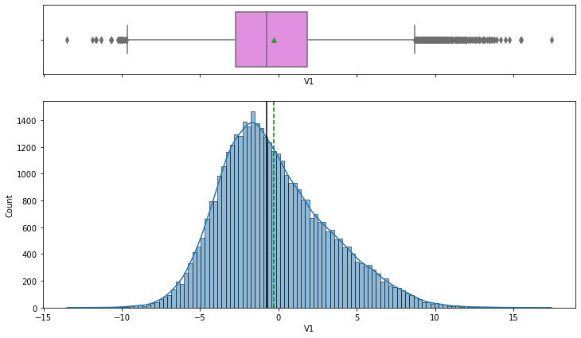

```python
# plot histogram and boxplot of V1
histogram_boxplot(df, 'V1')
```

#### V1 Observations

- V1 is slightly skewed in the positive direction but otherwise looks like an approximately normal distribution
- Outliers in both directions
- Negative mean and median

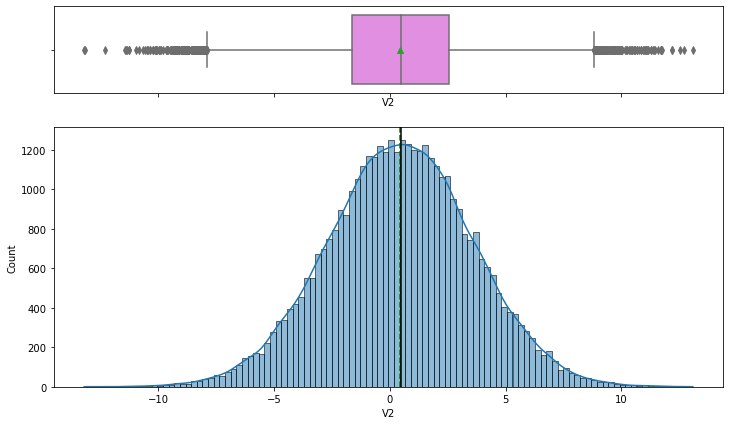

```python
# plot histogram and boxplot of V2
histogram_boxplot(df, 'V2')
```

#### V2 Observations

- Approximately normal distribution
- Outliers in both directions
- Positive mean and median

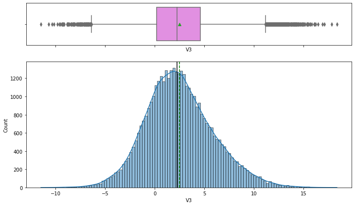

```python
# plot histogram and boxplot of V3
histogram_boxplot(df, 'V3')
```

#### V3 Observations

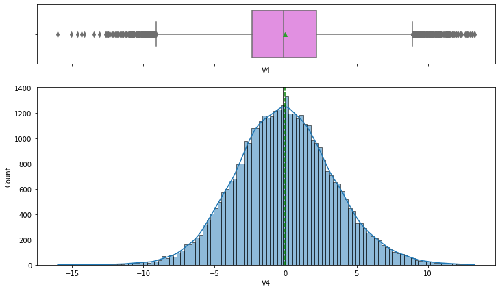

```python
# plot histogram and boxplot of V4
histogram_boxplot(df, 'V4')
```

#### V4 Observations

- V4 has an approximately normal distribution
- Outliers in both directions
- Negative mean and median

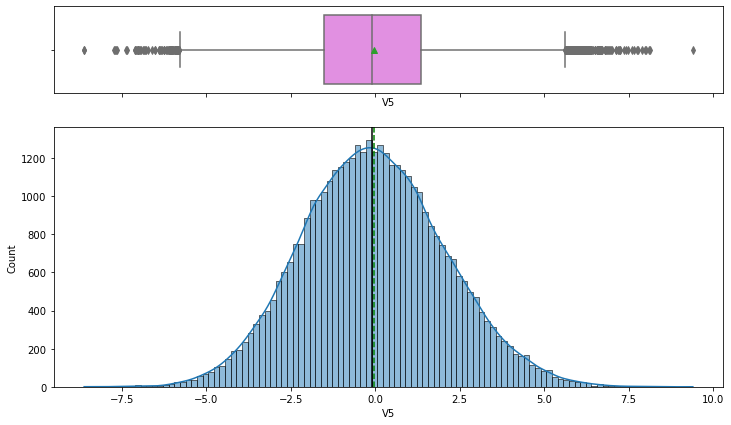

```python
# plot histogram and boxplot of V5
histogram_boxplot(df, 'V5')
```

#### V5 Observations

- V5 has an approximately normal distribution
- Outliers in both directions
- Mean and median close to zero, but negative

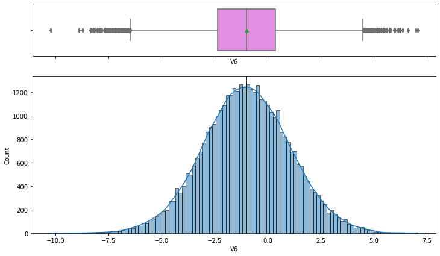

```python
# plot histogram and boxplot of V6
histogram_boxplot(df, 'V6')
```

#### V6 Observations

- V6 has an approximately normal distribution
- Outliers in both directions
- Negative mean and median

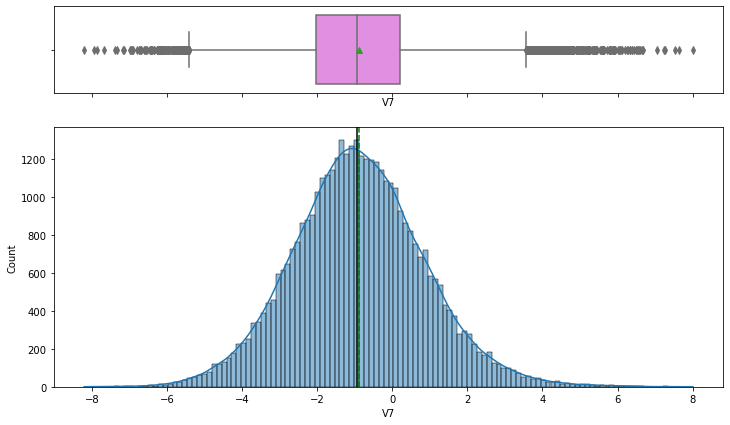

```python
# plot histogram and boxplot of V7
histogram_boxplot(df, 'V7')
```

#### V7 Observations

- V7 has an approximately normal distribution
- Outliers in both directions
- Negative mean and median

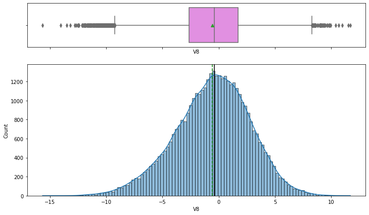

```python
# plot histogram and boxplot of V8
histogram_boxplot(df, 'V8')
```

#### V8 Observations

- V8 has a slight negative skew
- Outliers in both directions
- Negative mean and median

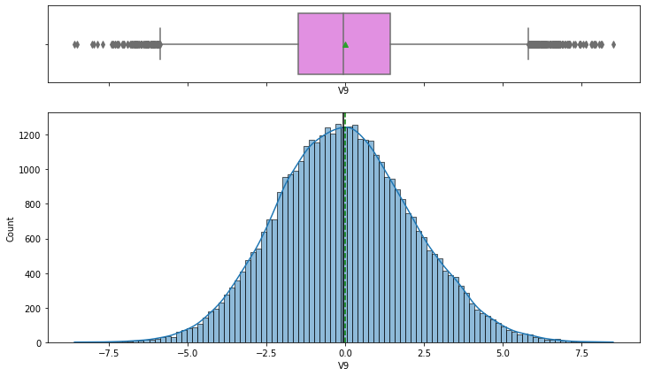

```python
# plot histogram and boxplot of V9
histogram_boxplot(df, 'V9')
```

#### V9 Observations

- V9 has an approximately normal distribution
- Outliers in both directions
- Mean and median approximately zero (negative)

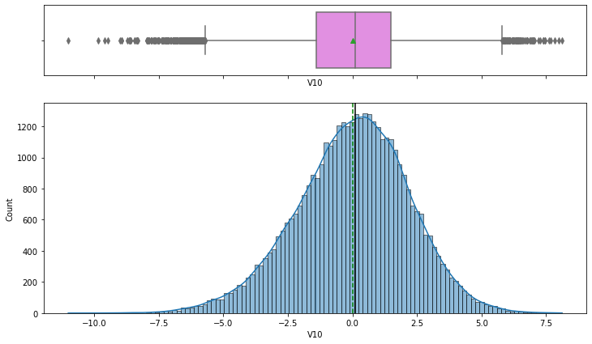

```python
# plot histogram and boxplot of V10
histogram_boxplot(df, 'V10')
```

#### V10 Observations

- V10 has a slight negative skew
- Outliers in both directions
- Mean negative (approximately zero) and median positive

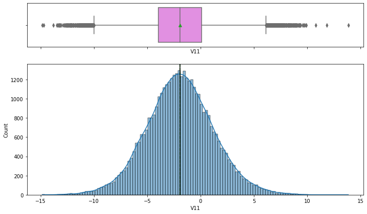

```python
# plot histogram and boxplot of V11
histogram_boxplot(df, 'V11')
```

#### V11 Observations

- V11 has an approximately normal distribution
- Outliers in both directions
- Negative mean and median

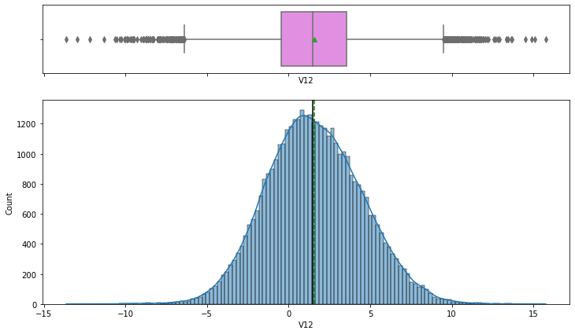

```python
# plot histogram and boxplot of V12
histogram_boxplot(df, 'V12')
```

#### V12 Observations

- V12 has a slight positive skew
- Outliers in both directions
- Positive mean and median

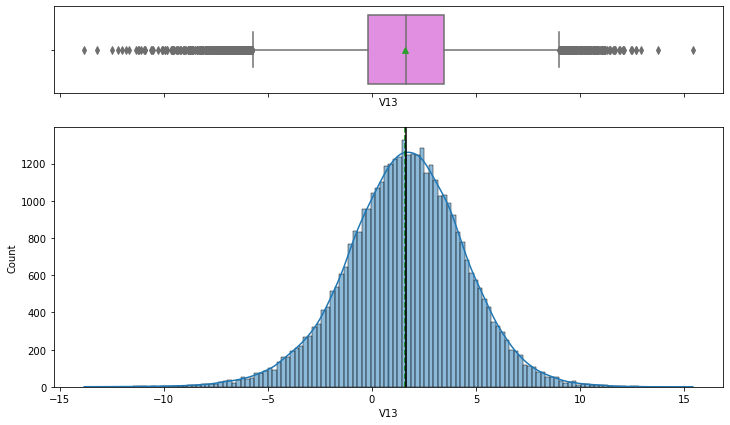

```python
# plot histogram and boxplot of V13
histogram_boxplot(df, 'V13')
```

#### V13 Observations

- V13 has an approximately normal distribution
- Outliers in both directions
- Positive mean and median

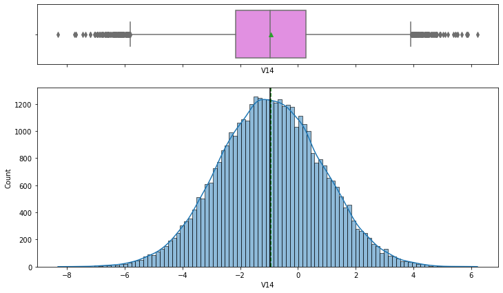

```python
# plot histogram and boxplot of V14
histogram_boxplot(df, 'V14')
```

#### V14 Observations

- V14 has an approximately normal distribution
- Outliers in both directions
- Negative mean and median

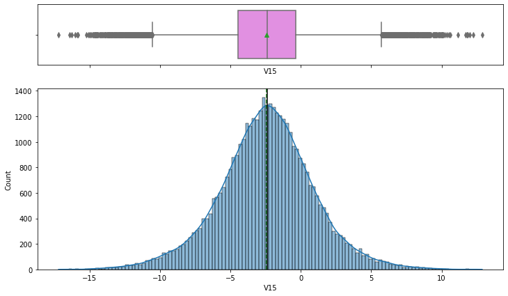

```python
# plot histogram and boxplot of V15
histogram_boxplot(df, 'V15')
```

#### V15 Observations

- V15 has an approximately normal distribution
- Outliers in both directions
- Mean and median negative

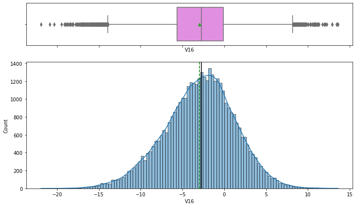

```python
# plot histogram and boxplot of V16
histogram_boxplot(df, 'V16')
```

#### V16 Observations

- V16 has a slight negative skew
- Outliers in both directions
- Mean and median both negative

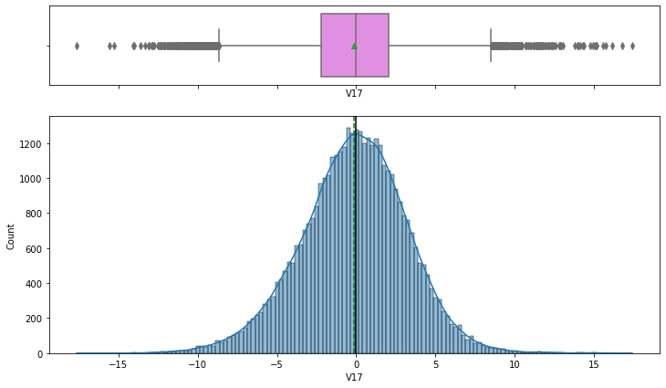

```python
# plot histogram and boxplot of V17
histogram_boxplot(df, 'V17')
```

#### V17 Observations

- V17 has an approximately normal distribution
- Outliers in both directions
- Mean and median approximately zero (negative)

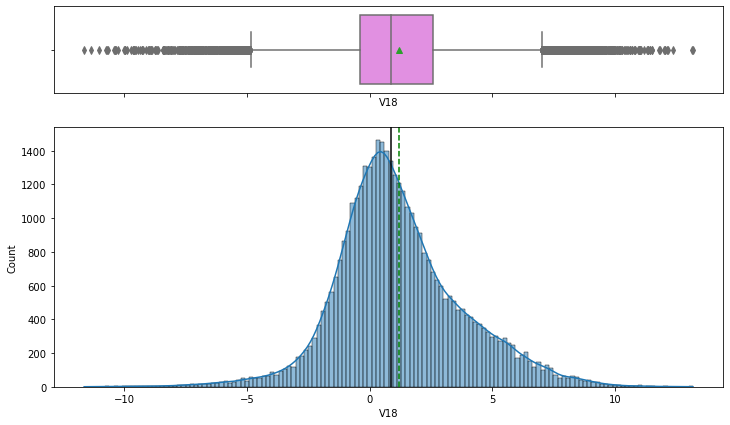

```python
# plot histogram and boxplot of V18
histogram_boxplot(df, 'V18')
```

#### V18 Observations

- V18 has a positive skew
- Outliers in both directions
- Mean and median are both positive

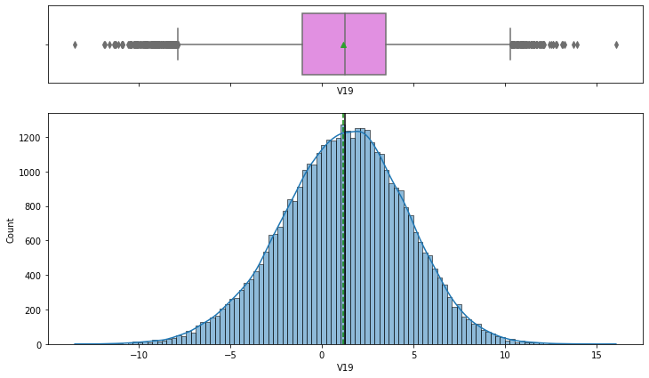

```python
# plot histogram and boxplot of V19
histogram_boxplot(df, 'V19')
```

#### V19 Observations

- V19 has an approximately normal distribution
- Outliers in both directions
- Mean and median both positive

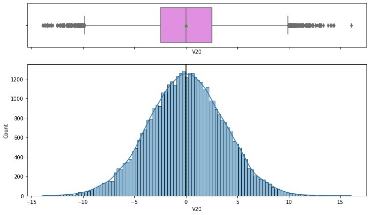

```python
# plot histogram and boxplot of V20
histogram_boxplot(df, 'V20')
```

#### V20 Observations

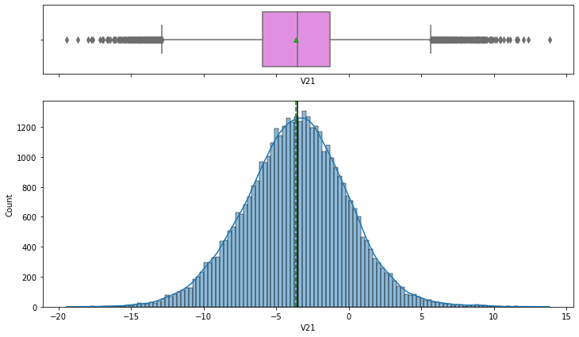

```python
# plot histogram and boxplot of V21
histogram_boxplot(df, 'V21')
```

#### V21 Observations

- V21 has an approximately normal distribution
- Outliers in both directions
- Mean and median both negative

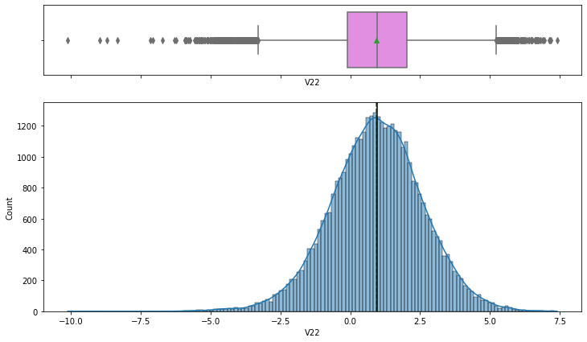

```python
# plot histogram and boxplot of V22
histogram_boxplot(df, 'V22')
```

#### V22 Observations

- V22 has an approximately normal distribution
- Outliers in both directions, but negative direction outliers much farther from the measure of center
- Mean and median both positive

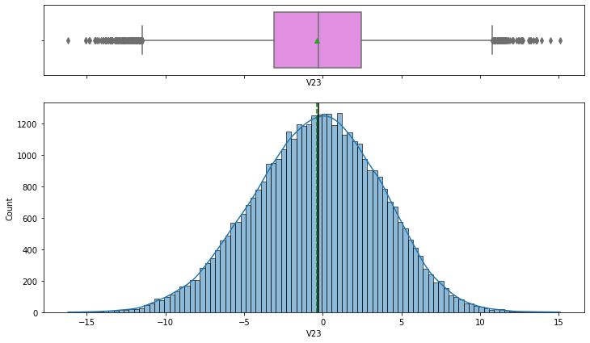

```python
# plot histogram and boxplot of V23
histogram_boxplot(df, 'V23')
```

#### V23 Observations

- V23 has an approximately normal distribution
- Outliers in both directions
- Mean and median are negative, close to zero

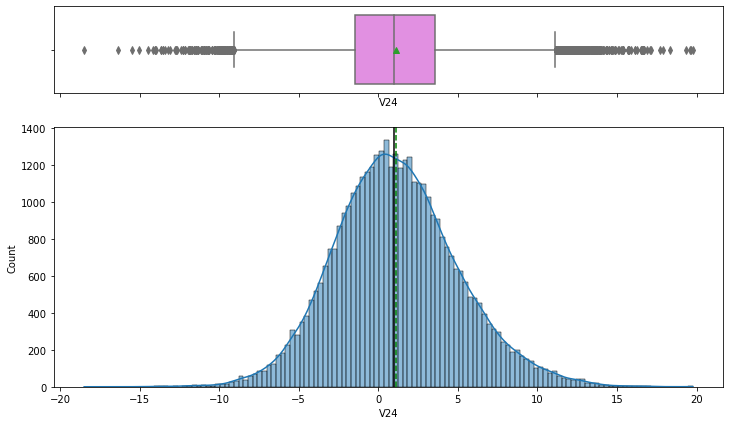

```python
# plot histogram and boxplot of V24
histogram_boxplot(df, 'V24')
```

#### V24 Observations

- V24 has an approximately normal distribution with a slight positive skew
- Outliers in both directions
- Mean and median both positive

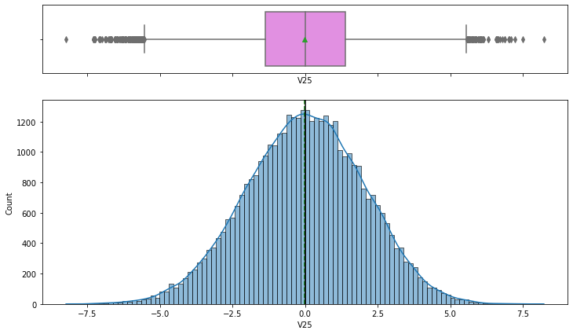

```python
# plot histogram and boxplot of V25
histogram_boxplot(df, 'V25')
```

#### V25 Observations

- V25 has an approximately normal distribution
- Outliers in both directions
- Mean and median approximately zero

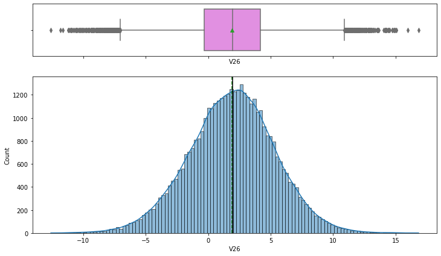

```python
# plot histogram and boxplot of V26
histogram_boxplot(df, 'V26')
```

#### V26 Observations

- V26 has an approximately normal distribution
- Outliers in both directions
- Mean and median both positive

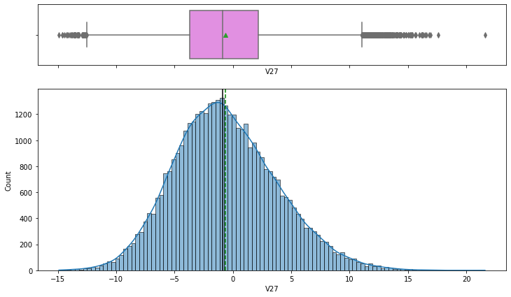

```python
# plot histogram and boxplot of V27
histogram_boxplot(df, 'V27')
```

#### V27 Observations

- V27 has a slight positive skew
- Outliers in both directions
- Mean and median both negative

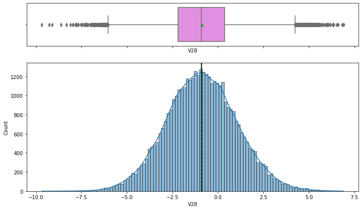

```python
# plot histogram and boxplot of V28
histogram_boxplot(df, 'V28')
```

#### V28 Observations

- V28 has an approximately normal distribution
- Outliers in both directions
- Mean and median negative

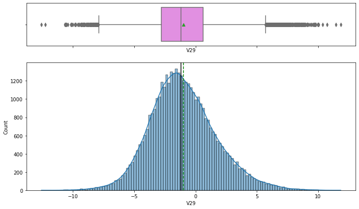

```python
# plot histogram and boxplot of V29
histogram_boxplot(df, 'V29')
```

#### V29 Observations

- V29 has a slight positive skew
- Outliers in both directions
- Mean and median negative

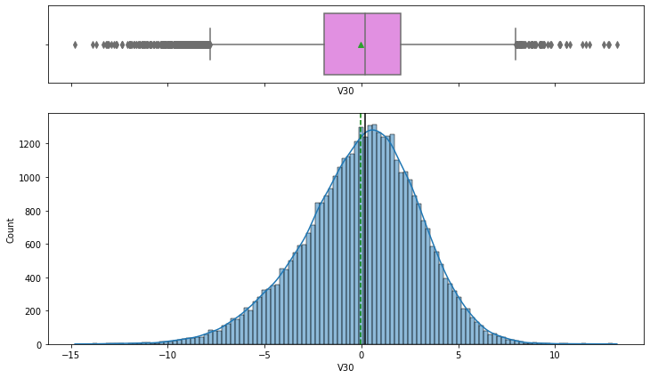

```python
# plot histogram and boxplot
histogram_boxplot(df, 'V30')
```

#### V30 Observations

- Slight negative skew
- Outliers in both directions
- Mean negative, median positive

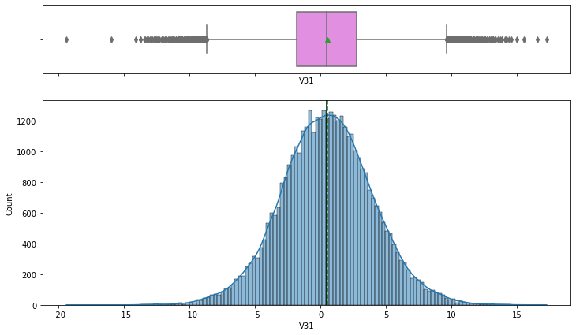

```python
# plot histogram and boxplot of V31
histogram_boxplot(df, 'V31')
```

#### V31 Observations

- V31 has an approximately normal distribution
- Outliers in both directions
- Mean and median both positive

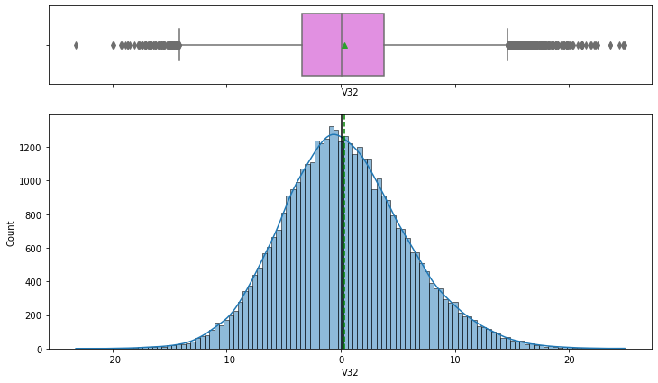

```python
# plot histogram and boxplot of V32
histogram_boxplot(df, 'V32')
```